# Sampling distributions, hypothesis testing, statistical power

### From Last Week

Randomization produces unbiased estimates of the ATE. But our single experiment is only one of many possible random assignments that could have occurred.

This fact produces uncertainty surrounding our estimate of the “true” ATE. A different random assignment to treatment and control would most likely have produced different estimates.

Today, we will explore how to reduce this uncertainty during the design phase of an experiment.

### Distribution of ATEs

Consider a simplified version of last week’s SAT example.

| Illustration of potential outcomes, depending on whether an individual takes a prep course | Illustration of potential outcomes, depending on whether an individual takes a prep course SAT if no prep | Illustration of potential outcomes, depending on whether an individual takes a prep course SAT if prep | Illustration of potential outcomes, depending on whether an individual takes a prep course Difference |
| --- | --- | --- | --- |
| Alex | 300 | 400 | 100 |
| Bonnie | 300 | 400 | 100 |
| Colin | 500 | 600 | 100 |
| Danielle | 500 | 600 | 100 |
| Earl | 700 | 800 | 100 |
| Fiona | 700 | 800 | 100 |
| AVERAGE | 500 | 600 | 100 |

Suppose we conduct an experiment where 2 out of these 6 people are randomly assigned to take the SAT prep course.

**Class exercise:**

1. Write out all of the possible ways that random assignment could have taken place (hint: there should be 15 in total).
2. For each possible randomization, calculate the treatment mean, the control mean, and the ATE.
3. Show that the average of the possible randomizations equals the “true” ATE of 100.

**Key Takeaways**

On average, our experiment produces an unbiased estimate of the ATE.

However, depending on exactly which randomization was realized, the results of any individual single experiment varied widely.

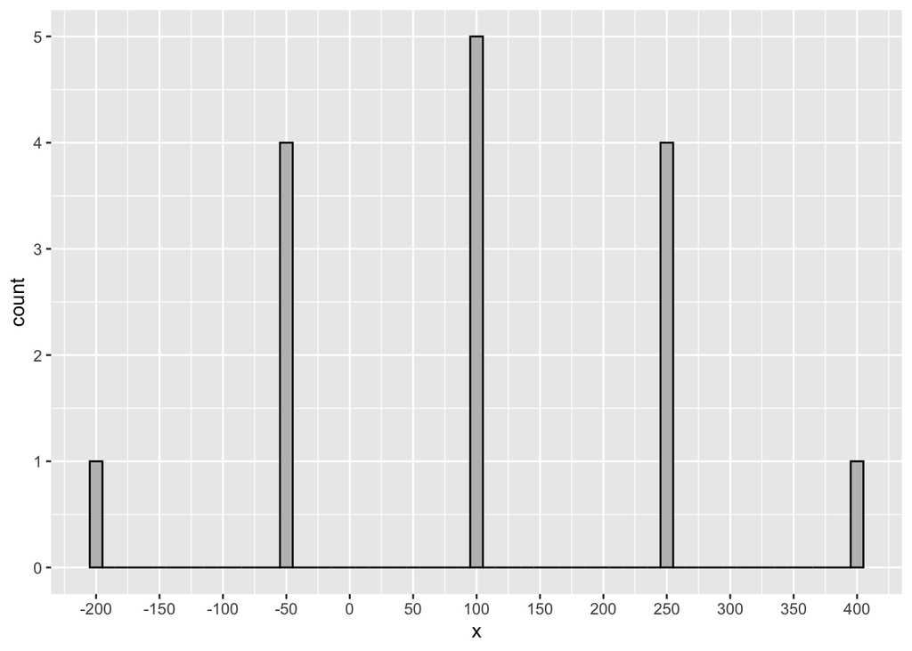

We could have estimated an ATE as low as -200, and as high as 400.

33% of the time our estimate would have been negative.

### Reducing Uncertainty

- Increase the sample size (if you have the time and budget)
  - Sometimes, it’s possible to at least increase the size of the control group at little cost!
- Put more resources into T or C depending on which potential outcomes have higher variance
  - Requires some pilot data first
  - Without priors, best bet is to opt for 50-50
- Measuring outcomes better
  - Reduce measurement error
  - Use multiple items, combine them into scales
- Decrease variance in potential outcomes:
  - Blocking
  - Pre-post designs

**Here’s a nice problem illustrating tradeoffs:**

A new experiment aims to estimate the effect of receiving text message reminders on vaccination uptake.

- One hundred and fifty clinics, each with 600 eligible patients, are willing to participate.
- There is a fixed cost of USD 100 for each clinic you want to work with, and it costs USD 1 for each text message that you want to send.
- Any clinics that you are working with will measure the outcome for free.
- Assume that you have a budget of USD 1,000.

Under what conditions might it be better to focus your resources on a small number of clinics and under what conditions might it be better to spread them more widely?

### Blocking

In our working SAT example, there were basically 3 types of students:

- Poor performers (Alex and Bonnie)
- Average performers (Colin and Danielle)
- Good performers (Earl and Fiona)

Under some randomizations, both good performers (or poor performers) receive the treatment. Notice that these cases produce the most extreme ATE estimates.

Blocking groups together individuals with similar potential outcomes, and treatments are randomly assigned within these blocks. This procedure can dramatically reduce uncertainty.

**Class exercise:**

4. Write out all of the possible ways that blocked random assignment could have taken place (hint: there should be 8 in total).
5. For each possible randomization, calculate the treatment mean, the control mean, and the ATE.

| Here’s a more realistic example with two blocks: | Here’s a more realistic example with two blocks: Block | Here’s a more realistic example with two blocks: Y(C) | Here’s a more realistic example with two blocks: Y(T) |
| --- | --- | --- | --- |
| 1 | A | 0 | 0 |
| 2 | A | 1 | 0 |
| 3 | A | 2 | 1 |
| 4 | A | 4 | 2 |
| 5 | A | 4 | 0 |
| 6 | A | 6 | 0 |
| 7 | A | 6 | 2 |
| 8 | A | 9 | 3 |
| 9 | B | 14 | 12 |
| 10 | B | 15 | 9 |
| 11 | B | 16 | 8 |
| 12 | B | 16 | 15 |
| 13 | B | 17 | 5 |
| 14 | B | 18 | 17 |

Imagine two possible designs:

- Under complete randomization where 4 out of 14 individuals are randomly assigned to treatment, there would be 1001 possible assigments
- Under blocked assignment, 2 individuals in each block are assigned to treatment. Now there are only 420 possible randomizations.

To calculate the ATE in a blocked design, calculate the ATE separately for each block. The overall ATE is just a weighted average of the separate block ATEs.

Here:

- ATE for block A = -3
- ATE for block B = -5
- Overall ATE: (-3 * 8 / 14) + (-5 * 6 / 14) = -3.857

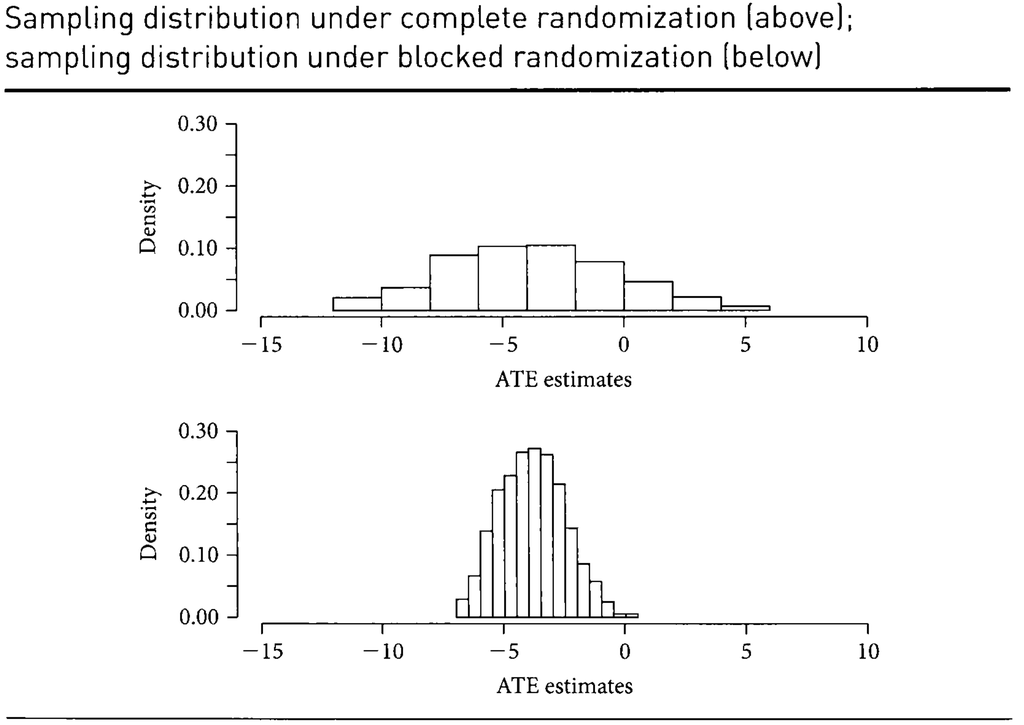

This “shrinkage” comes about because potential outcomes are much higher in Block B than in Block A. By estimating ATEs separately within each block, we eliminate this source of variance in potential outcomes.

More generally, blocking produces the greatest gains in precision when the variables used to form blocks strongly predict outcomes. Theory and prior (observational) research can provide clues about which covariates are the strongest predictors.

**IMPORTANT!** When we don’t have the full schedule of potential outcomes, you should not simply compare treatment vs control means for all subjects **if the probability of treatment differs across blocks.** Doing so generates a biased estimate of the ATE!

To understand why, note that the probability of treatment is higher in Block B (33%) than in Block A (25%).

But Block B also has higher potential outcomes.

In other words, Blocks are correlated with both treatment assignment and potential outcomes!

Without accounting for this fact, we get bias!

Note that this correlation only disappears in the special case that treatment probabilities are identical across blocks.

Here is another example from a study by Titiunik. The research examines the effects of politicians’ term length on their producitivity (measured as the number of bills introduced). Data come from Texas and Arkansas.

State senators usually serve four year terms.

However, senate districts are redrawn every 10 years (after the census)

In the first election after reapportionment all seats are up for election, but the seats are randomly assigned to two conditions:

**A.** Serve two years immediately after the election (and then two consecutive four-year terms), or

**B.** Serve four years immediately after the election (and then one four-year term and another two-year term).

Titiunik used the random assignment to two-year and four-year terms that occurred after the 2002 election under newly redrawn districts to study the effect of shorter terms on the number of bills introduced during the 2002–2003 legislative session.

**Class exercise:**

Please download the [data](https://nanzhangresearch.github.io/titiunik.csv).

6. For each state, estimate the effect of having a two-year term on the number of bills introduced in 2002-2003.
7. Estimate the overall ATE for both states combined.
8. Explain why simply pooling the data for the two states and comparing the average number of bills introduced by two-year senators to the average number of bills introduced by four-year senators leads to biased estimates of the overall ATE.

Beyond precision, blocking has several additional advantages.

First, it ensures that certain subgroups are available for separate analysis by guaranteeing that a specified proportion of a subgroup will be assigned to treatment.

For instance, imagine a study involving 10 men and 10 women. A researcher might be interested in comparing the ATE among men to the ATE among women.

But what if complete random assignment puts 9 of the 10 men into the treatment group and 9 of the 10 women in the control group? In that case, the treatment effects among men and among women would both be estimated very imprecisely.

Blocked randomization could be used to ensure that 5 women and 5 men are assigned to treatment.

Second, blocking can be used to address ethical constraints. Imagine that we enroll 100 students in our SAT study, and we have the budget to pay for 50 students to attend prep classes.

For ethical reasons, we may also want ensure that 60% of pre class spots go to “poor performers”.

Finally, suppose that 40 out of the 100 students are poor performers.

In this case, we could use the following design:

- 30 out of 40 poor performers are randomly selected to attend prep class
- 20 out of 60 remaining students are randomly selected to attend prep class

In this way, we ensure that the majority of prep class spots go to poor performing students.

### Pre-Post Designs

Another way to reduce variance in potential outcomes is via a pre-post design. Here, the researcher measures outcomes both before and after the intervention. The quantity of interest is the (within-individual) **change over time**. (See Enos’ trains experiment for an example).

Much like in our blocking example, since pre-treatment outcomes also likely predictive of (post-experimental) potential outcomes, differencing them out will also increase precision.

One way to think about this in the context of the SAT example is that there is a lot of natural variation in people’s SAT scores, so this makes comparing the treatment and control conditions difficult: it is hard to detect a relative small effect in noisy outcome data. But if you difference-out this naturally occurring variability, then there is much less variability, and that makes it easier to detect a small effect.

To see the statistical value of moving to a **difference-in-differences** design, consider the following [schedule of potential outcomes](https://nanzhangresearch.github.io/40schools.csv).

Here, **X** denotes pre-treatment test scores, **Y(1)** is the potential outcome if the subject receives treatment, and **Y(0)** is the potential outcome if the subject is in the control group.

**Group exercise:**

9. What are the means and standard deviations of **Y(1)** and **Y(0)**?
10. What is the difference-in-means ATE?
11. Create variables **D(0) = Y(0) - X** and **D(1) = Y(1) - X**. What are the means and standard deviations of **D(0)** and **D(1)**?
12. What is the difference-in-differences ATE?

**Shrinkage in Distribution of ATEs**

In this example, the pre-test is strongly predictive of potential outcomes.

Here’s the distribution of ATEs with and without first-differencing the outcomes.

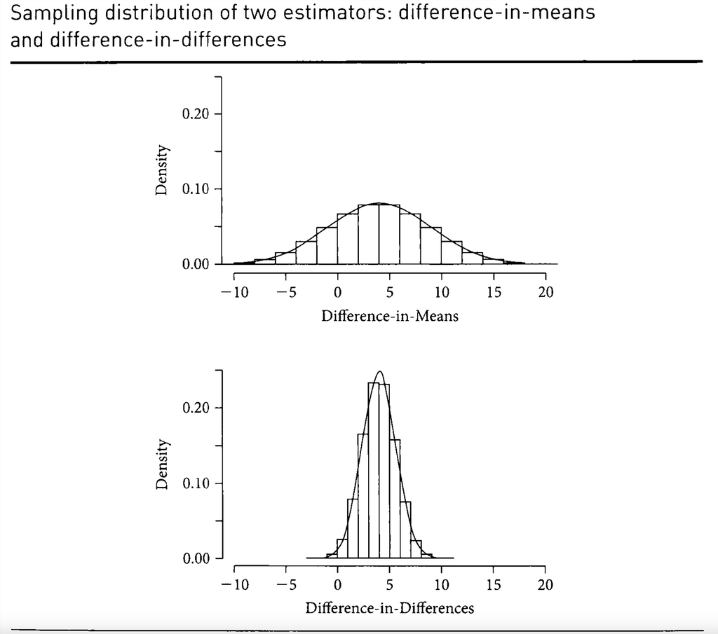

This implies that researchers should take advantage of opportunities to gather background information that may be useful in predicting potential outcomes.

Another idea would be to deliberately focus interventions on subjects for whom background information is readily available.

But be careful! A pre-test may “give away the game”, thus jeopardizing the assumption of excludability.

For example, in Enos’ experiment, what if the pre-test questions about immigration make people more attentive the presence of immigrants in their surroundings?

In this case, the experiment would measure a combination of the causal effect of the treatment and the causal effect of taking the pre-test.

### Hypothesis testing

Writing out a schedule of potential outcomes (even if some cells are missing) suggests a way to conduct hypothesis tests.

Here, we will focus on the *sharp null hypothesis* that the treatment effect is zero for all observations. Importantly, we can use the *sharp null hypothesis* to fill in the missing cells in our potential outcomes schedule.

With our now completed schedule of potential outcomes, we can then simulate all possible randomizations. These simulated randomizations provide an exact sampling distribution of the estimated ATE under the sharp null hypothesis.

By looking at this distribution of hypothetical outcomes, we can calculate the probability of obtaining an estimated ATE at least as large as the one we obtained from our actual experiment if the treatment effect were in fact zero for every subject. In other words, we can compute p-values.

This procedure is called **randomization inference**.

Note that this same procedure can also be applied to blocked designs. The only differnce is that blocking must be taken into account when simulating the set of possible randomizations.

Let’s work through a simple example by hand:

| Results from a single experiment on the effects of SAT prep | Results from a single experiment on the effects of SAT prep SAT if no prep | Results from a single experiment on the effects of SAT prep SAT if prep |
| --- | --- | --- |
| Alex | 300 | ? |
| Bonnie | 300 | ? |
| Colin | 500 | ? |
| Danielle | ? | 600 |
| Earl | 700 | ? |
| Fiona | ? | 800 |

**Class exercise:**

13. What is the estimated ATE under this single experiment?
14. Fill in the missing cells under the sharp null hypothesis.
15. Calculate the ATE under the sharp null hypothesis for each of the 15 possible random assignments.
16. What is the p-value associated with your estimate?

Here’s a working example (with R code) that also explores the statistical advantages of conducting pre-tests.

A researcher working with elementary school students sought to improve students’ ability to solve logic puzzles. Students in the treatment and control group initially took a pre-test and the number of correctly solved puzzles was recorded.

A few days later, students assigned to the control group were then given 30 minutes to improve their puzzle-solving skills by doing practice problems on their own.

At the same time, students in the treatment group listened to an instructor describe some rules of thumb to keep in mind when solving logic puzzles.

All subjects then took a post-test, and the number of correctly solved puzzles was recorded.

| Imagine that here are the results for all 18 subjects: | Imagine that here are the results for all 18 subjects: Treatment | Imagine that here are the results for all 18 subjects: Pretest | Imagine that here are the results for all 18 subjects: Posttest | Imagine that here are the results for all 18 subjects: Improvement |
| --- | --- | --- | --- | --- |
| 1 | 1 | 10 | 10 | 0 |
| 2 | 1 | 9 | 11 | 2 |
| 3 | 1 | 5 | 6 | 1 |
| 4 | 1 | 3 | 6 | 3 |
| 5 | 1 | 3 | 6 | 3 |
| 6 | 1 | 6 | 7 | 1 |
| 7 | 1 | 6 | 7 | 1 |
| 8 | 1 | 5 | 6 | 1 |
| 9 | 1 | 6 | 7 | 1 |
| 10 | 0 | 9 | 9 | 0 |
| 11 | 0 | 6 | 7 | 1 |
| 12 | 0 | 11 | 10 | -1 |
| 13 | 0 | 4 | 5 | 1 |
| 14 | 0 | 3 | 3 | 0 |
| 15 | 0 | 10 | 10 | 0 |
| 16 | 0 | 7 | 8 | 1 |
| 17 | 0 | 7 | 7 | 0 |
| 18 | 0 | 8 | 10 | 2 |

```r
library(ri2)

# Load the data
prepost_data = data.frame(Z = c(1,1,1,1,1,1,1,1,1,0,0,0,0,0,0,0,0,0),
                          Y=c(10,11,6,6,6,7,7,6,7,9,7,10,5,3,10,8,7,10))

# Declare randomization procedure
declaration <- declare_ra(N = 18, m = 9)

# Conduct Randomization Inference
ri2_out <- conduct_ri(
  formula = Y ~ Z,
  declaration = declaration,
  sharp_hypothesis = 0,
  data = prepost_data
)

# Output: ATE and the associated p-value
summary(ri2_out)
```

```
##   term   estimate two_tailed_p_value
## 1    Z -0.3333333              0.811
```

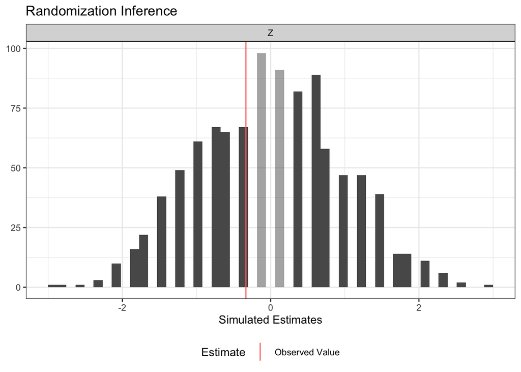

```r
# Displying the sampling distribution of all possible randomizations under the sharp null
plot(ri2_out)
```

**Group exercise:**

Here’s the [data as a csv](https://nanzhangresearch.github.io/prepost_data.csv).

17. Consider the difference between post- and pre-test scores. What is the difference-in-differences estimate of the ATE and its associated p-value?
18. Test the null hypothesis that the pre-test scores are unaffected by treatment assignment. Why might you want to do this?

Randomization inference might be preferred over standard statistical tests because the method is not confined to large samples or normally distributed outcomes.

Any sample size will do, and the method can be applied to all sorts of outcomes, including counts, durations, or ranks.

Otherwise, if you have large samples, regression will give you pretty much the same result (see next classs).

### Statistical Power

But at some point, if you don’t have enough participants, you will fail to reject the null even if the treatment does, in fact, exert an effect on outcomes.

Researchers often attempt to forecast the probability that their experiment, when conducted, will lead to the rejection of the null hypothesis at a given significance level.

This probability is termed the **statistical power** of the experiment. To say that an experimental design has 80% power means that 80% of all possible random assignments will produce observed results that will lead to the rejection of the null hypothesis if the posited treatment effect in fact exists.

It is good practice to analyze the power of your experimental design before data collection so that you can be sure that you have budgeted sufficient time and resources.

However, this requires some guesswork about the “true” treatment effect (or at least, the minimum treatment effect that is substantively meaningful).

```r
# 1. Create the full potential outcomes schedule
# ----------------------------------------------

# set seed allows us to create the same dataset every time
set.seed(1)

# Sample size
sampsize = 50

# Potential outcomes if assigned to control group
y0 = rnorm(sampsize)

# Potential outcomes if assigned to treatment group
# Notice that the treatment effect is exactly 1sd for every individual
y1 = y0 + 1

# Putting the data together
data = data.frame(y0, y1)

# Declare randomization procedure
declaration <- declare_ra(N = sampsize, m = sampsize/2)


# 2. Assign to T and C for one single experiment
# ----------------------------------------------

# set seed allows us to change treatment assignments
set.seed(6)

# assigning to T and C
# Create a new variable Y to denote the observed outcomes based on treatment assignment
data2 <- data %>%
    mutate(Z=sample(rep(c(0,1), length=n()))) %>%
    mutate(Y = if_else(Z==0,y0,y1))

# Conduct Randomization Inference
ri2_out <- conduct_ri(
  formula = Y ~ Z,
  declaration = declaration,
  sharp_hypothesis = 0,
  data = data2
)

# Output: ATE and the associated p-value
summary(ri2_out)

# Displying the sampling distribution of all possible randomizations under the sharp null
plot(ri2_out)


# Now go back to the top of step 2 and set a new seed
# This is like running a new experiment on the same population (and same schedule of potential outcomes)
# The only thing which changes is the actual allocation to T and C
# How does the resulting ATE and p-value in your "new" experiment?



# 3. Use a loop to repeat step 2 a large number of times.
# -------------------------------------------------------

# Think of this as running a large number of "new" experiments using the same population
# In how many of these new experiments will you obtain a statistically significant treatment effect
# (given that the "true" ATE = 1)?

# Here we define an "empty" dataset to store the all of the results of our replications
df=data.frame()

# This is the loop, set up to conduct 100 replications
for(i in 1:100){

  set.seed(i)

  data2 <- data %>%
    mutate(Z=sample(rep(c(0,1), length=n()))) %>%
    mutate(Y = if_else(Z==0,y0,y1))

  ri2_out <- conduct_ri(
    formula = Y ~ Z,
    declaration = declaration,
    sharp_hypothesis = 0,
    data = data2
  )

  # Here I'm picking out the p-value
  x <- summary(ri2_out) %>%
    select(two_tailed_p_value)

  # and saving the p-value to the "empty" dataset
  df = rbind(df, x)

}


# Now tagging all of the replications which produced a statistically significant result
df <- df %>%
    mutate(statsig = ifelse(two_tailed_p_value < 0.05, 1, 0))

# Here is your power
mean(df$statsig)



## You can go back to step 1, play around with the sample size and the "true" effect size, and see how your power changes.
## You can also try out different types of DVs (e.g. dichotomous variables, count variables, etc)
## Also, see what happens when you put unequal numbers of people into T and C
```

### Next week:

- Adjusting for covariates using regression
- Balance tests
- Pre-registration and pre-analysis plans
- Ethical design